# Computer Lab 3

Introduction to Machine Learning

Emil K Svensson

# Assignment 1

## 1.1

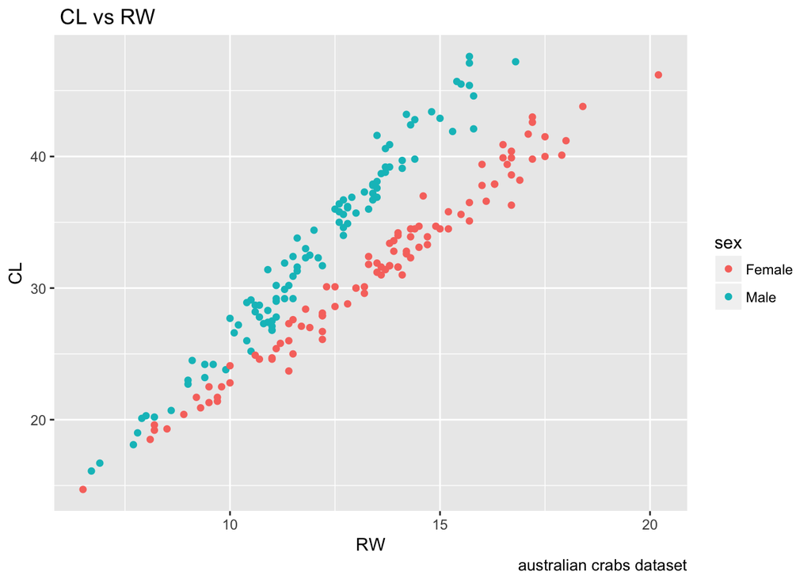

```r
crabs <- read.csv("australian-crabs.csv")
library(ggplot2)
p <- ggplot(data = crabs) + geom_point(aes(x = RW, y = CL, col = sex)) + labs(title = " CL vs RW",
    caption = "australian crabs dataset")
plot(p)
```

A line would be able to separate the genders pretty well. One could expect a couple of missclassifications when the variables has low values as the genders seem to have less separation there.

## 1.2

```r
LDA <- function(X) {

    RW <- X[, 1]
    CL <- X[, 2]
    sex <- X[, 3]
    myMu <- aggregate(cbind(RW, CL), by = list(sex), FUN = mean, simplify = TRUE)
    myCov <- by(cbind(RW, CL), list(sex), cov, method = "pearson")
    myPi <- aggregate(cbind(RW, CL), by = list(sex), FUN = function(x) length(x)/nrow(cbind(RW,
        CL)), simplify = TRUE)


    mySig <- ((myCov[[1]] * myPi[2, 2] * length(RW)) + (myCov[[2]] * myPi[2,
        3] * length(RW)))/nrow(X)


    woMale <- -0.5 * as.matrix(myMu[2, 2:3], ncol = 2) %*% solve(mySig) %*%
        t(myMu[2, 2:3]) + log(myPi[2, 3])
    woFem <- -0.5 * (as.matrix(myMu[1, 2:3], ncol = 2)) %*% solve(mySig) %*%
        t(myMu[1, 2:3]) + log(myPi[1, 3])


    wM <- solve(mySig) %*% t(myMu[2, 2:3])
    wF <- solve(mySig) %*% t(myMu[1, 2:3])


    a <- (woMale - woFem)
    b <- wM - wF
    x <- cbind(X[, 1:2])

    # w0s is a w1s is b[1] w2s is b[2]
    myInter <- as.numeric(-a/b[2])
    mySlope <- as.numeric(-b[1]/b[2])

    X$myClass <- t(ifelse((a[1] + t(b) %*% t(x)) > 0, levels(X[, 3])[2], levels(X[,
        3])[1]))
    colnames(X)[4] <- "Predicted"
    retObj <- list(w0 = c(woMale, woFem), w1 = cbind(wM = wM, wF = wF), myClass = X,
        myModel = c(myInter = myInter, mySlope = mySlope))

    return(retObj)
}
```

The return object of the LDA-function returns a list with all answers and the decision boundary.

To get the decision boundary we have the set the two discriminantfunctions equal to each other and solve for one of the parameters depending on X so that we get where they intercect.

$\delta_k(x) = x^T\Sigma^{-1}\mu_k + (-1/2)\Sigma^{-1}\mu_k + log(\pi_k)$

$w_{i} = \Sigma^{-1}\mu_i$ $w_{oi} = (-1/2)\Sigma^{-1}\mu_k + log(\pi_k)$

$\delta_{male}(x) = \delta_{female}(x)$

$\delta_{male}(x) - \delta_{female}(x) = 0$

$x^T(w_{Male} - w_{Female}) + (w_{0 Male} - w_{0 Female}) = 0$

$x^T_{CL}(w_{Male} - w_{Female}) +x^T_{RW}(w_{Male} - w_{Female}) + (w_{0 Male} - w_{0 Female}) = 0$

$x^T_{RW}(w_{Male} - w_{Female}) + (w_{0 Male} - w_{0 Female}) = -x^T_{CL}(w_{Male} - w_{Female})$

$(x^T_{RW}(w_{Male} - w_{Female}) + (w_{0 Male} - w_{0 Female}) )/ -(w_{Male} - w_{Female}) = x^T_{CL}$

## 1.3

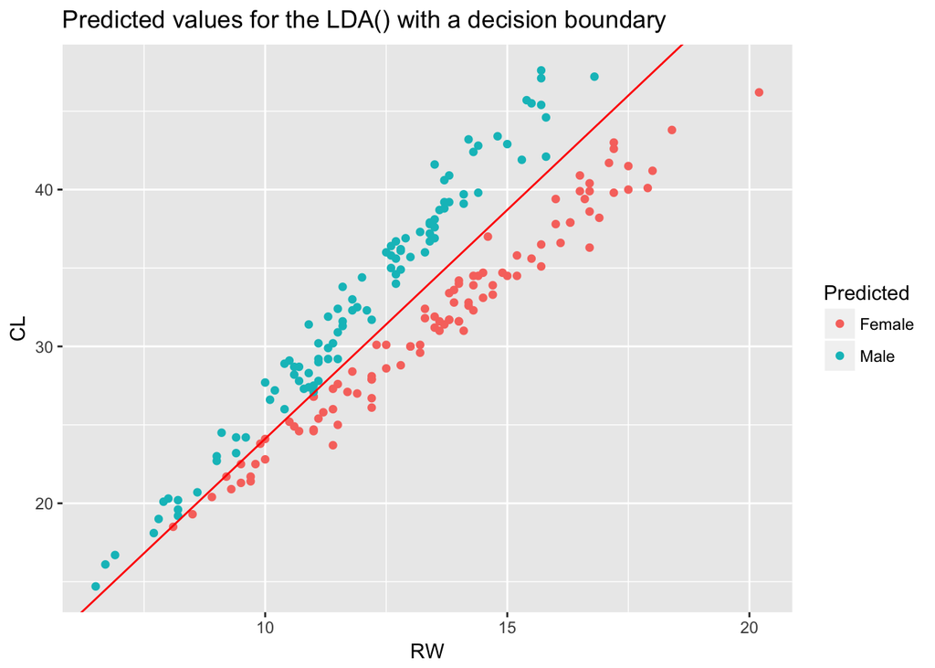

```r
results <- LDA(crabs[, c(5, 6, 2)])
## 2.3 actualdata + desicion boundaries p + geom_abline(intercept =
## results$myModel[1], slope = results$myModel[2], col = 'Red')

# predicted classes + desicion boundaries
ggplot(data = results$myClass) + geom_point(aes(x = RW, y = CL, col = Predicted)) +
    geom_abline(intercept = results$myModel[1], slope = results$myModel[2],
        col = "Red") + labs(title = "Predicted values for the LDA() with a decision boundary")
```

The line was calculated to

$$-5.0656387+ x^T_{RW}(2.9180154) = x^T_{CL}$$

The decision line divides the data nicely but i has some issiues when RW is below 12 where the two groups are closer in distance.

The two discriminant functions were calculated to

$$\delta_{male}(x) = x^T(-12.5634175) + 2.5658514$$
$$\delta_{female}(x) = x^T(-22.4287694) + -0.2138144$$

## 1.4

```r
myLogit <- glm(sex ~ RW + CL, family = binomial(link = "logit"), data = crabs)
```

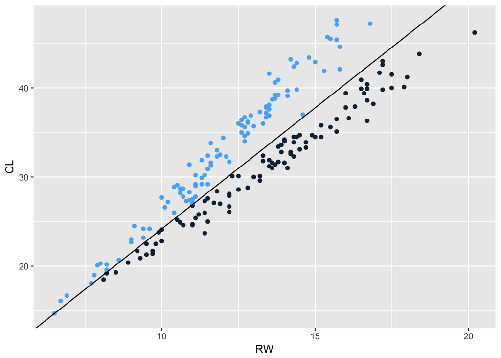

```r
myDecLog <- coef(myLogit)[1:2]/-coef(myLogit)[3]

ggplot(data = results$myClass) + geom_point(aes(x = RW, y = CL, col = ifelse(myLogit$fitted.values >
    0.5, 1, 0)), show.legend = FALSE) + geom_abline(intercept = myDecLog[1],
    slope = myDecLog[2])
```

One visible difference in the plots are that an observation located close to the line at CL = 37 and RW = 14 is now classified as a male wheras it was classified as a female. Other than this it is hard to disguinsh any visible diffrences.

```r
cat("For the Logistic regression \n")
```

```
## For the Logistic regression
```

```r
t(table(Predicted = ifelse(myLogit$fitted.values > 0.5, "Male", "Female"), Observed = crabs$sex))
```

```
##         Predicted
## Observed Female Male
##   Female     97    3
##   Male        4   96
```

```r
cat("\n")
```

```r
cat("For the LDA:\n")
```

```
## For the LDA:
```

```r
t(table(Predicted = results$myClass[, 4], Observed = crabs$sex))
```

```
##         Predicted
## Observed Female Male
##   Female     97    3
##   Male        4   96
```

Both classifiers has the same missclassificationrate 7/200 and has the same amount (but not necessery the same) of missclassifications in the anti-diagonals for the different categories.

# Assignment 2

## 2.1

```r
CS <- read.csv2("creditscoring.csv")

# Suffle the rows
set.seed(12345)
CS <- CS[sample(nrow(CS)), ]

# Divide them up in different sets
csTrain <- CS[1:(nrow(CS) * 0.5), ]
csValid <- CS[((nrow(CS) * 0.5) + 1):floor(nrow(CS) * 0.75), ]
csTest <- CS[((nrow(CS) * 0.75) + 1):nrow(CS), ]
```

## 2.2

|  | Train | Test |
| --- | --- | --- |
| Deviance | 0.212 | 0.248 |
| Gini | 0.240 | 0.304 |

The Gini splitting criterion has a higher training and missclassification rate than the deviance splitting criterion. So for the following step the deviance criterion is used.

## 2.3

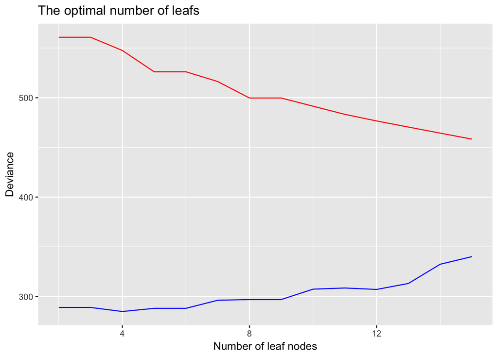

```r
valid23 <- data.frame(trainS = 1, testS = 1)
tDev2 <- tree(good_bad ~ ., data = csTrain, split = "deviance")
rad <- 1

for (i in 2:15) {
    tDev22 <- prune.tree(tDev2, best = i)
    valid23[rad, 1] <- deviance(tDev22)
    valid23[rad, 2] <- deviance(predict(tDev22, newdata = csValid, type = "tree"))
    rad <- rad + 1
}

valid23$best <- 2:15
ggplot(data = valid23, aes(x = best)) + geom_line(aes(y = trainS), col = "red") +
    geom_line(aes(y = testS), col = "blue") + labs(title = "The optimal number of leafs",
    x = "Number of leaf nodes", y = "Deviance", legend = c("Test", "Train"))
```

The optimal tree is the the one with 4 leafs is the optimal tree as it has the lowest validation deviance weher the training deviance is the lowest before it starts to rise again.

```r
best <- prune.tree(tDev2, best = 4)
summary(best)
```

```
##
## Classification tree:
## snip.tree(tree = tDev2, nodes = c(5L, 3L, 9L))
## Variables actually used in tree construction:
## [1] "savings"  "duration" "history"
## Number of terminal nodes:  4
## Residual mean deviance:  1.117 = 547.5 / 490
## Misclassification error rate: 0.251 = 124 / 494
```

```r
predTest <- predict(best, csTest)
tT <- table(ifelse(predTest[, 1] > predTest[, 2], "bad", "good"), csTest$good_bad)
paste("Missclassification rate for test data", 1 - (sum(diag(tT))/nrow(csTest)))
```

```
## [1] "Missclassification rate for test data 0.248"
```

The tree uses the variables Savings, duration and history for the decision boundaries. The missclassification rate is 0.251 which is worse than the initial model, although the mcr for the test (2.48) is actualy lower than the mcr for the traning data.

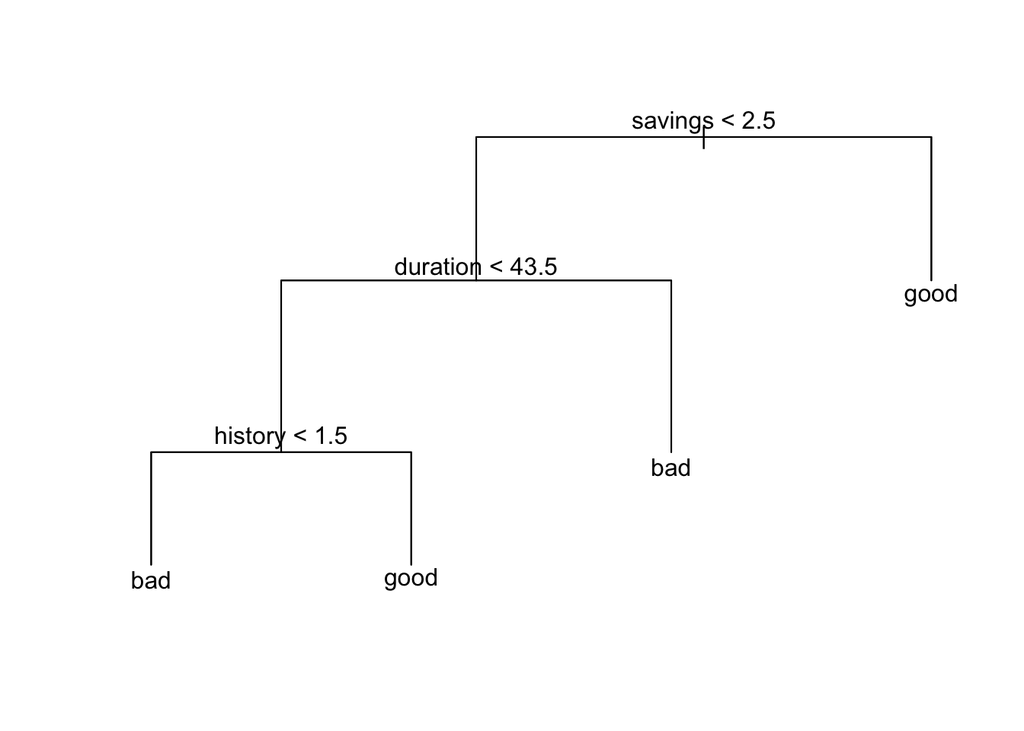

```r
plot(best)
text(best)
```

## 2.4

```r
library(e1071)
# ??e1071
cat("Training data")
```

```
## Training data
```

```r
cat("\n")
```

```r
baybay <- naiveBayes(formula = good_bad ~ ., data = csTrain)
bBay <- table(Predicted = predict(baybay, newdata = csTrain), Observed = csTrain$good_bad)
print(bBay/nrow(csTrain))
```

```
##          Observed
## Predicted   bad  good
##      bad  0.190 0.196
##      good 0.104 0.510
```

```r
1 - sum(diag(bBay))/nrow(csTrain)
```

```
## [1] 0.3
```

```r
cat("\n Test data")
```

```
##
##  Test data
```

```r
cat("\n")
```

```r
bBayTest <- table(Predicted = predict(baybay, newdata = csTest), Observed = csTest$good_bad)
print(bBayTest/nrow(csTest))
```

```
##          Observed
## Predicted   bad  good
##      bad  0.208 0.212
##      good 0.088 0.492
```

```r
1 - sum(diag(bBayTest))/nrow(csTest)
```

```
## [1] 0.3
```

The mcr is the same for both traning and test data, In the confusion-matrix the proportions are displayed instead of the raw numbers. These proportions looks to be very similary distrubuted compared to each other. Overall these predictions are worse than the decision tree in 2.3.

## 2.5

```r
rawprobs <- predict(baybay, csTrain, type = "raw")

rawBayes <- rawprobs[, 2]/rawprobs[, 1]  #good/bad

lossMat <- matrix(c(0, 10, 1, 0), ncol = 2)


lossBayBay <- table(Predicted = ifelse(rawBayes > lossMat[2, 1]/lossMat[1, 2],
    "Good", "Bad"), Observed = csTrain$good_bad)
# table(Predicted=ifelse(rawBayes > lossMat[1,2]/lossMat[2,1],'Good','Bad'
# ),Observed=csTrain$good_bad)
print(lossBayBay)
```

```
##          Observed
## Predicted bad good
##      Bad  137  263
##      Good  10   90
```

```r
1 - sum(diag(lossBayBay))/nrow(csTrain)
```

```
## [1] 0.546
```

```r
rawprobsTest <- predict(baybay, csTest, type = "raw")

rawBayesTest <- rawprobsTest[, 2]/rawprobsTest[, 1]  #good/bad
lossTable <- table(Predicted = ifelse(rawBayesTest > lossMat[2, 1]/lossMat[1,
    2], "Good", "Bad"), Observed = csTest$good_bad)
print(lossTable)
```

```
##          Observed
## Predicted bad good
##      Bad   66  134
##      Good   8   42
```

```r
1 - sum(diag(lossTable))/nrow(csTest)
```

```
## [1] 0.568
```

We now classify more observations as Bad although they are Good. That has to do with the Lossfunction we implemented that says that we need to be 10 times as sure than normal that a prediction is Good for us to classify it as a good pretiction. Because of this every observation that would normaly be classified as “good” when the probability for good is larger than bad now needs to be 10 times larger than bad for it to be good.